# Getting My Colleagues Hooked on R

2018-05-25

## What 9 of you wanted to learn

- for **5** of you:
  - Data visualization
- for **4** of you:
  - Fast code (via C++)
- for **3** of you:
  - Use of out-of-RAM matrices (Big Data)
  - Interactive plots
  - Interactive apps (Shiny)
  - Some features of RStudio (THE IDE of R)
- for **2** of you:
  - Some stats/analytics about the growth/use of R
  - Statistic models
  - Fast code (via tips such as vectorization)
  - Manipulation of datasets
  - comment créer un projet propre sous R, destiné a devenir un package
  - ggplot
- for **1** of you:
  - Parallel computing
  - Where to go to learn R
  - plutot une presentation générale des fonctionnalités, de la syntaxe + interaction avec python !

## Overview

We will try to see a bit of everything.

- This is only a (small) part of what R can do
- We will only see introductions to each topic, with some links to learn more
- I'm not an expert in everything in R (yet :D)

Contents:

- some stats about R
- data manipulation and visualization
- Rcpp
- bigmemory
- RStudio
- learn more

## Some facts about the growth of R:

- R is #5 of all programming languages ([IEEE Spectrum, July 2016](https://www.r-bloggers.com/r-moves-up-to-5th-place-in-ieee-language-rankings/))

[figure not shown]

- There are now 9307 available packages on CRAN ([CRAN: Contributed Packages, 2018-05-25](https://cran.r-project.org/web/packages/))

[figure not shown]

- There are many R conferences:
  - useR!: 900+ people in 2016,
  - eRum: european R users meeting,
  - EARL: many people from the Industry,
  - Rencontres R: Grenoble in 2015,
  - satRdays,
  - R/Finance & R in Insurance.
- The R blogosphere is huge: [R-bloggers](https://www.r-bloggers.com/) has
  - nearly 600 bloggers,
  - 36K followers on Twitter,
  - 39K on Facebook,
  - very interesting posts every day!

## Manipulating data? Ask Hadley Wickham!

R packages that he has developped (from [his website](http://hadley.nz/)):

- Data science
  - [ggplot2](http://ggplot2.org) for visualising data.
  - dplyr for manipulating data.
  - tidyr for tidying data.
  - stringr for working with strings.
  - lubridate for working with date/times.
- Data import
  - readr for reading .csv and fwf files.
  - readxl for reading .xls and .xlsx files.
  - haven for SAS, SPSS, and Stata files.
  - httr for talking to web APIs.
  - rvest for scraping websites.
  - xml2 for importing XML files.
- Software engineering
  - devtools for general package development.
  - [roxygen2](http://github.com/klutometis/roxygen) for in-line documentation.
  - testthat for unit testing.

## Introduction to dplyr (from its vignette)

```r
p_load(nycflights13)
dim(flights)
[1] 336776     19
head(flights)
# A tibble: 6 × 19
   year month   day dep_time sched_dep_time dep_delay arr_time
  <int> <int> <int>    <int>          <int>     <dbl>    <int>
1  2013     1     1      517            515         2      830
2  2013     1     1      533            529         4      850
3  2013     1     1      542            540         2      923
4  2013     1     1      544            545        -1     1004
5  2013     1     1      554            600        -6      812
6  2013     1     1      554            558        -4      740
# ... with 12 more variables: sched_arr_time <int>, arr_delay <dbl>,
#   carrier <chr>, flight <int>, tailnum <chr>, origin <chr>, dest <chr>,
#   air_time <dbl>, distance <dbl>, hour <dbl>, minute <dbl>,
#   time_hour <dttm>
```

```r
p_load(dplyr)
```

Dplyr aims to provide a function for each basic verb of data manipulation:

- `filter()` (and `slice()`)
- `arrange()`
- `select()` (and `rename()`)
- `distinct()`
- `mutate()` (and `transmute()`)
- `summarise()`
- `sample_n()` (and `sample_frac()`)

```r
filter(flights, month == 1, day == 1)
```

```
# A tibble: 842 × 19
    year month   day dep_time sched_dep_time dep_delay arr_time
   <int> <int> <int>    <int>          <int>     <dbl>    <int>
1   2013     1     1      517            515         2      830
2   2013     1     1      533            529         4      850
3   2013     1     1      542            540         2      923
4   2013     1     1      544            545        -1     1004
5   2013     1     1      554            600        -6      812
6   2013     1     1      554            558        -4      740
7   2013     1     1      555            600        -5      913
8   2013     1     1      557            600        -3      709
9   2013     1     1      557            600        -3      838
10  2013     1     1      558            600        -2      753
# ... with 832 more rows, and 12 more variables: sched_arr_time <int>,
#   arr_delay <dbl>, carrier <chr>, flight <int>, tailnum <chr>,
#   origin <chr>, dest <chr>, air_time <dbl>, distance <dbl>, hour <dbl>,
#   minute <dbl>, time_hour <dttm>
```

```r
arrange(flights, desc(dep_delay))
```

```
# A tibble: 336,776 × 19
    year month   day dep_time sched_dep_time dep_delay arr_time
   <int> <int> <int>    <int>          <int>     <dbl>    <int>
1   2013     1     9      641            900      1301     1242
2   2013     6    15     1432           1935      1137     1607
3   2013     1    10     1121           1635      1126     1239
4   2013     9    20     1139           1845      1014     1457
5   2013     7    22      845           1600      1005     1044
6   2013     4    10     1100           1900       960     1342
7   2013     3    17     2321            810       911      135
8   2013     6    27      959           1900       899     1236
9   2013     7    22     2257            759       898      121
10  2013    12     5      756           1700       896     1058
# ... with 336,766 more rows, and 12 more variables: sched_arr_time <int>,
#   arr_delay <dbl>, carrier <chr>, flight <int>, tailnum <chr>,
#   origin <chr>, dest <chr>, air_time <dbl>, distance <dbl>, hour <dbl>,
#   minute <dbl>, time_hour <dttm>
```

```r
mutate(flights, gain = arr_delay - dep_delay,
  speed = distance / air_time * 60)
```

```
# A tibble: 336,776 × 21
    year month   day dep_time sched_dep_time dep_delay arr_time
   <int> <int> <int>    <int>          <int>     <dbl>    <int>
1   2013     1     1      517            515         2      830
2   2013     1     1      533            529         4      850
3   2013     1     1      542            540         2      923
4   2013     1     1      544            545        -1     1004
5   2013     1     1      554            600        -6      812
6   2013     1     1      554            558        -4      740
7   2013     1     1      555            600        -5      913
8   2013     1     1      557            600        -3      709
9   2013     1     1      557            600        -3      838
10  2013     1     1      558            600        -2      753
# ... with 336,766 more rows, and 14 more variables: sched_arr_time <int>,
#   arr_delay <dbl>, carrier <chr>, flight <int>, tailnum <chr>,
#   origin <chr>, dest <chr>, air_time <dbl>, distance <dbl>, hour <dbl>,
#   minute <dbl>, time_hour <dttm>, gain <dbl>, speed <dbl>
```

```r
flights2 <- flights %>%
  filter(month == 1, day == 1) %>%
  arrange(desc(dep_delay)) %>%
  mutate(gain = arr_delay - dep_delay,
         speed = distance / air_time * 60)
print(flights2, n = 6)
```

```
# A tibble: 842 × 21
   year month   day dep_time sched_dep_time dep_delay arr_time
  <int> <int> <int>    <int>          <int>     <dbl>    <int>
1  2013     1     1      848           1835       853     1001
2  2013     1     1     2343           1724       379      314
3  2013     1     1     1815           1325       290     2120
4  2013     1     1     2205           1720       285       46
5  2013     1     1     1842           1422       260     1958
6  2013     1     1     2115           1700       255     2330
# ... with 836 more rows, and 14 more variables: sched_arr_time <int>,
#   arr_delay <dbl>, carrier <chr>, flight <int>, tailnum <chr>,
#   origin <chr>, dest <chr>, air_time <dbl>, distance <dbl>, hour <dbl>,
#   minute <dbl>, time_hour <dttm>, gain <dbl>, speed <dbl>
```

## Elegant visualization tools: [ggplot2](http://ggplot2.org/)

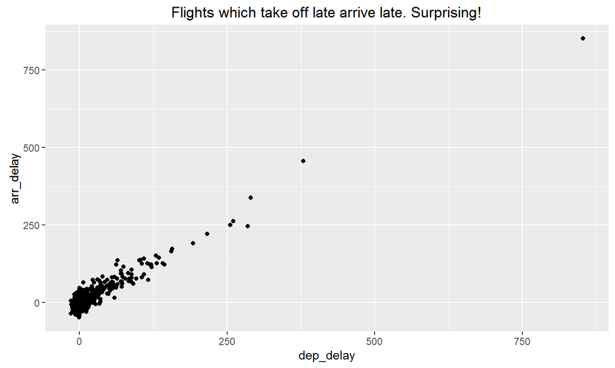

```r
p_load(ggplot2)
p <- qplot(dep_delay, arr_delay, data = flights2,
      main = "Flights which take off late arrive late. Surprising!")
print(p)
```

## Adding layers

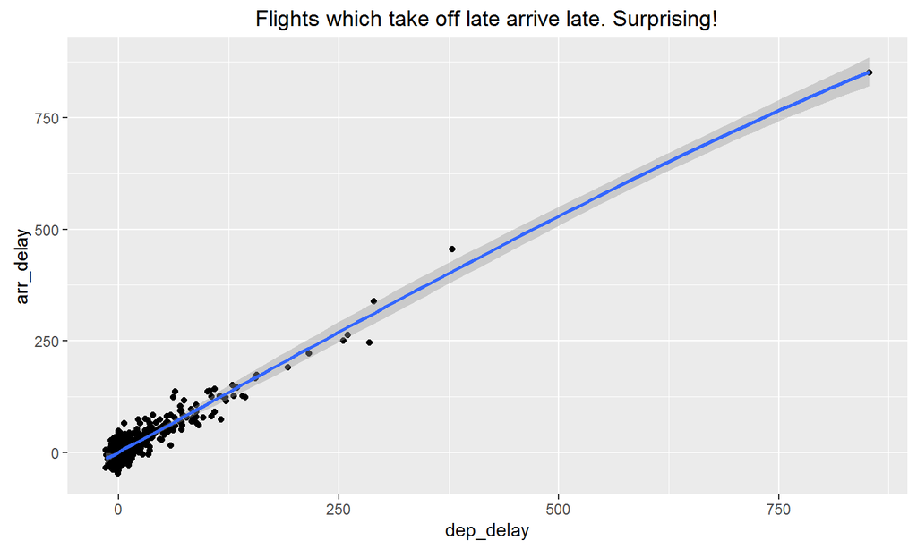

```r
p + geom_smooth()
```

## More: go check this book

```r
citation("ggplot2")
```

```
  H. Wickham. ggplot2: Elegant Graphics for Data Analysis.
  Springer-Verlag New York, 2009.

A BibTeX entry for LaTeX users is

  @Book{,
    author = {Hadley Wickham},
    title = {ggplot2: Elegant Graphics for Data Analysis},
    publisher = {Springer-Verlag New York},
    year = {2009},
    isbn = {978-0-387-98140-6},
    url = {http://ggplot2.org},
  }
```

## Some extensions are available [here](https://www.ggplot2-exts.org/)

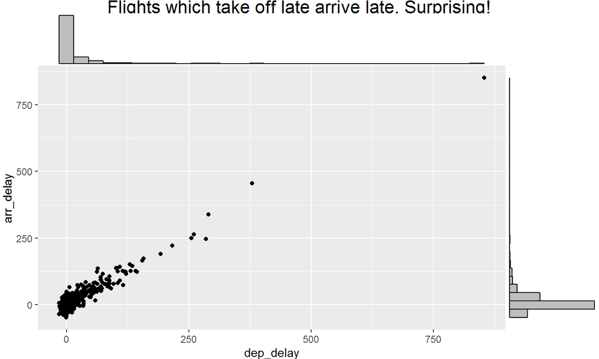

```r
p_load(ggExtra)
ggMarginal(p, type = "histogram")
```

## ggmap: maps with ggplot2

[figure not shown]

## Interactive visualizations tools: [plotly](https://plot.ly/ggplot2/)

```r
p_load(plotly)
ggplotly(p)
```

[interactive chart not shown]

## More

Looking for inspiration or help concerning data visualisation with R? Go check the [R graph gallery](http://www.r-graph-gallery.com/)!

## Interactive apps: [Shiny](http://shiny.rstudio.com/)

Live demo!

- From the Shiny website
- My own shiny app: `shiny::runGitHub("privefl/repartitions_equipes")`
- A game: [Lights Out](https://daattali.com/shiny/lightsout/)

More advanced usage: [Advanced tips and tricks](https://github.com/daattali/advanced-shiny)

## Use of C++ code when needed

More infos [there](http://adv-r.had.co.nz/Rcpp.html)

Typical bottlenecks that C++ can address include:

- Recursive functions, or problems which involve calling functions **millions of times**.
- Loops that **can’t be easily vectorised** because subsequent iterations depend on previous ones.
- Problems that require **advanced data structures** and algorithms that R doesn’t provide.

## Sum

```r
sumR <- function(x) {
  total <- 0
  for (i in seq_along(x)) {
    total <- total + x[i]
  }
  total
}
```

[figure not shown]

In Rcpp:

```cpp
#include <Rcpp.h>
using namespace Rcpp;

// [[Rcpp::export]]
double sumC(NumericVector x) {
  int n = x.size();
  double total = 0;
  for(int i = 0; i < n; ++i) {
    total += x[i];
  }
  return total;
}
```

In [Rcpp Sugar](http://dirk.eddelbuettel.com/code/rcpp/Rcpp-sugar.pdf):

```cpp
#include <Rcpp.h>
using namespace Rcpp;

// [[Rcpp::export]]
double sumCS(NumericVector x) {
  return sum(x);
}
```

Microbenchmark:

```r
p_load(microbenchmark)

x <- runif(1e3)

microbenchmark(
  sum(x),
  sumC(x),
  sumCS(x),
  sumR(x)
)
```

```
Unit: microseconds
     expr     min       lq      mean   median       uq      max neval
   sum(x)   1.624   1.9160   2.25361   2.0205   2.1310    6.616   100
  sumC(x)   3.501   4.0135   5.45615   4.3500   5.2285   27.545   100
 sumCS(x)   3.567   4.0395   4.97736   4.4040   5.1380   16.425   100
  sumR(x) 483.268 504.4415 586.03832 548.2945 616.3200 1926.567   100
```

## Gibbs sampler

```r
gibbs_r <- function(N, thin) {
  mat <- matrix(nrow = 2, ncol = N)
  x <- y <- 0

  for (i in 1:N) {
    for (j in 1:thin) {
      x <- rgamma(1, 3, y * y + 4)
      y <- rnorm(1, 1 / (x + 1), 1 / sqrt(2 * (x + 1)))
    }
    mat[, i] <- c(x, y)
  }
  mat
}
```

```cpp
#include <Rcpp.h>
using namespace Rcpp;

// [[Rcpp::export]]
NumericMatrix gibbs_cpp(int N, int thin) {
  NumericMatrix mat(2, N);
  double x = 0, y = 0;

  for(int i = 0; i < N; i++) {
    for(int j = 0; j < thin; j++) {
      x = rgamma(1, 3, 1 / (y * y + 4))[0];
      y = rnorm(1, 1 / (x + 1), 1 / sqrt(2 * (x + 1)))[0];
    }
    mat(0, i) = x;
    mat(1, i) = y;
  }

  return(mat);
}
```

```r
microbenchmark(
  gibbs_r(100, 10),
  gibbs_cpp(100, 10)
)
```

```
Unit: microseconds
               expr      min        lq      mean   median       uq
   gibbs_r(100, 10) 5961.415 6185.3970 7178.3434 6526.775 7090.976
 gibbs_cpp(100, 10)  257.184  277.0105  302.6162  287.633  301.857
       max neval
 45224.159   100
  1470.401   100
```

## Bigmemory

- On-disk matrices
- types: `char`, `short`, `int`, `float`, `double`
- Access with `[i, j]` as a matrix
- Access via C++ code with `[j][i]`
- Easy use of parallelisation with shared matrices

## Example with foreach and bigmemory

- Say you have:
- A SNP big.matrix X stored on-disk in directory *backingfiles*,
- Infos on the positions of the SNPs (the first 40,000 SNPs are in chromosome 1, then 38,000 are in chromosome 2, etc.),
- And you have to do some computations which are independent with respect to chromosomes. You want to use **Parallel Computing**!
- How to do use Parallel Computing on massive genotype matrices?

```r
DO_all <- function(X, infos, ncores) {
  DO_chr <- function(X.desc, lims) {
    X.chr <- sub.big.matrix(X.desc,
                          firstCol = lims[1],
                          lastCol = lims[2],
                          backingpath = "backingfiles")
    ## Do something with X.chr (such as imputing)
  }
  range.chr <- LimsChr(infos)
  X.desc <- describe(X)
  obj <- foreach(chr = 1:nrow(range.chr),
                 .packages = "bigmemory")
  expr_fun <- function(chr) {
    DO_chr(X.desc, range.chr[chr, ])
  }
  res <- foreach2(obj, expr_fun, ncores)
}
```

```r
LimsChr <- function(infos) {
  map.rle <- rle(infos$map$chromosome)
  upper <- cumsum(map.rle$length)
  lower <- c(1, upper[-length(upper)] + 1)
  cbind(lower, upper, "chr" = map.rle$values)
}

foreach2 <- function(obj, expr_fun, ncores) {
  if (is.seq <- (ncores == 1)) {
    foreach::registerDoSEQ()
  } else {
    cl <- parallel::makeCluster(ncores)
    doParallel::registerDoParallel(cl)
  }
  res <- eval(parse(
    text = sprintf("foreach::`%%dopar%%`(obj, expr_fun(%s))",
                   obj$argnames)))
  if (!is.seq) parallel::stopCluster(cl)
  return(res)
}
```

## We have [RStudio](https://www.rstudio.com/)

Live demo!

- Code highlighting/autocompletion
- Help > Cheatsheets
- Panels (Git, …)
- debugger
- [Notebooks](https://www.r-bloggers.com/r-notebooks/)

More tips: [RStudio Tips](https://twitter.com/rstudiotips) on Twitter

## Free books to learn about R:

- Advanced R programming:
  - [Efficient R Programming](https://csgillespie.github.io/efficientR/preface.html)
  - [Advanced R](http://adv-r.had.co.nz/)
- Reporting:
  - [Getting used to R, RStudio, and R Markdown](https://ismayc.github.io/rbasics-book/index.html)
- Data analysis:
  - [R for Data Science](http://r4ds.had.co.nz/)
  - [An Introduction to Statistical Learning, with Applications in R](http://www-bcf.usc.edu/~gareth/ISL/) (Trevor Hastie is one of the 4 authors)
- Package development:
  - [R packages](http://r-pkgs.had.co.nz/)

Learn: [R Course Finder](http://r-exercises.com/r-courses/)

## References and further reading

- [7 Tips For Getting Your Colleagues Hooked on R](http://scl.io/QZxZZl6u#gs.zMhz76Q)
- [Video: What is R?](https://www.youtube.com/watch?v=TR2bHSJ_eck)
- [How Companies Use R to Compete in a Data-Driven World](http://data-informed.com/companies-use-r-compete-data-driven-world/)
- [How the growth of R helps data-driven organizations succeed](http://www.slideshare.net/RevolutionAnalytics/how-the-growth-of-r-helps-datadriven-organizations-succeed)
- [A segmented model of CRAN package growth](https://www.r-bloggers.com/a-segmented-model-of-cran-package-growth/)
- [Coke vs Soda vs Pop : Linguistic trends analyzed with Twitter and R](https://www.r-bloggers.com/coke-vs-soda-vs-pop-linguistic-trends-analyzed-with-twitter-and-r/)
- [rPython R package](http://rpython.r-forge.r-project.org/)
- [Feather: A Fast On-Disk Format for Data Frames for R and Python](https://www.r-bloggers.com/feather-a-fast-on-disk-format-for-data-frames-for-r-and-python-powered-by-apache-arrow/)